# Distribution

```r
library(lubridate)
```

tosscoin(3)

```r
s_three_coins <- tosscoin(3)
```

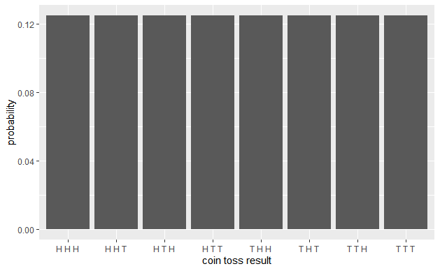

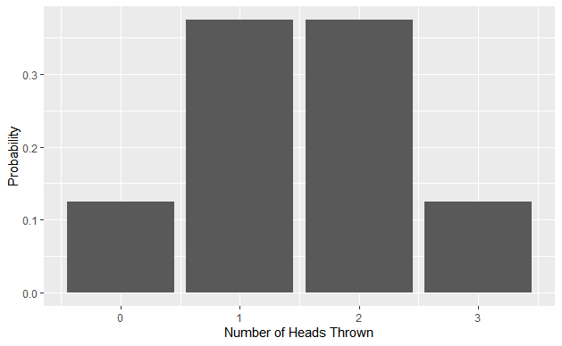

This gives us a *discrete* probability distribution.

```r
air_con_sales <- read_csv("data/AirConSales.csv") %>%
  clean_names() %>%
  mutate(date = as.Date(date, format = "%m/%d/%Y"))
```

| units_sold | n | percent |
| --- | --- | --- |
| 0 | 3 | 0.08108108 |
| 1 | 2 | 0.05405405 |
| 2 | 2 | 0.05405405 |
| 3 | 9 | 0.24324324 |
| 4 | 8 | 0.21621622 |
| 6 | 3 | 0.08108108 |
| 8 | 1 | 0.02702703 |
| 9 | 1 | 0.02702703 |
| 10 | 2 | 0.05405405 |
| 11 | 3 | 0.08108108 |

[output cut: 2 more lines]

```r
freqs <- tabyl(rolls) %>%
  as.tibble()
```

[output not shown]

[output not shown]

**If all we knew about the die were these results, then the empirical probabilities** **would be our best estimate of the behaviour of the die**

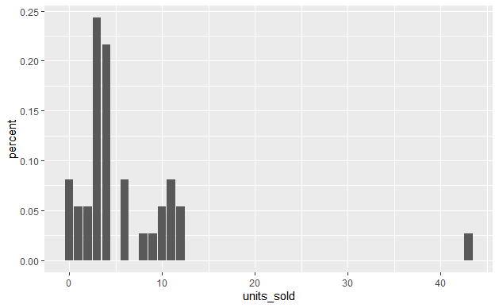

## Distribution Centres

Described by mean, median, and mode.

Mean is given the symbol μ for population or x̄ for a sample

Median is the value for which one-half of the values in the data set lie below it and on-half above.

R makes this calculation easy with the `median()` function.

```r
get_mode <- function(data){

  tabled_data <- table(data)
  table_names <- names(tabled_data)

  return( table_names[tabled_data == max(tabled_data)])
}
```

| mean_daily_sales | mode_daily_sales |
| --- | --- |
| 5.945946 | 3 |

```r
library(e1071)
```

[output not shown]

```r
right_skewed <- read_csv("data/rightskew.csv")
```

| skewness |
| --- |
| -1.011889 |

| skewness |
| --- |
| 0.6736541 |

| skewness |
| --- |
| 3.824317 |

## Measures of spread

Measures of spread - range, quartiles, interquartile range

Boxplots

Definition of an outlier from the interquartile range

Sample variances

```r
jobs <- read_csv("data/TyrellCorpJobs.csv") %>%
  clean_names()
```

| x1 | position | salary |
| --- | --- | --- |
| 1 | Accounting | 34397 |
| 2 | Accounting | 30359 |
| 3 | Management | 50036 |
| 4 | Accounting | 34716 |
| 5 | Accounting | 35786 |
| 6 | Accounting | 34395 |

| salary_range |
| --- |
| 61568 |

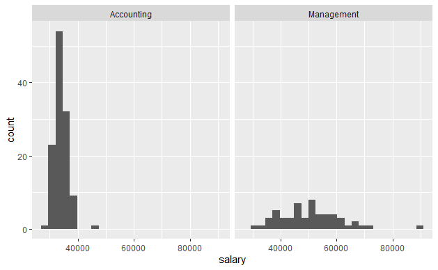

| position | range |
| --- | --- |
| Accounting | 15535 |
| Management | 59366 |

## Quartiles

Values split the distribution into sections

- Q1 = the value that splits the distribution into a lower 25% and higher 75%
- Q2 = The value that splits the distribution into a lower 50% and higher 50% (median)
- Q3 = The value that splits the distribution into a lower 75% and higher 25%

| position | Q1 | Q2 | Q3 |
| --- | --- | --- | --- |
| Accounting | 32390.5 | 34150 | 35265.0 |
| Management | 43698.0 | 50300 | 57288.5 |

**Inter-Quartile Range (IQR)**

$$IQR = Q3 - Q1$$

```r
jobs %>%
  group_by(position) %>%
  summarise(Q1 = quantile(salary, 0.25),
            Q2 = quantile(salary, 0.5),
            Q3 = quantile(salary, 0.75),
            IQR = Q3 - Q1)
```

[output not shown]

```r
jobs %>%
  select(-x1) %>%
  group_by(position) %>%
  skimr::skim()
```

```
── Data Summary ────────────────────────
                           Values
Name                       Piped data
Number of rows             175
Number of columns          2
_______________________
Column type frequency:
  numeric                  1
________________________
Group variables            position
```

|  | skim_variable | position | n_missing | complete_rate | mean | sd | p0 | p25 | p50 | p75 | p100 | hist |
| --- | --- | --- | --- | --- | --- | --- | --- | --- | --- | --- | --- | --- |
| 1 | salary | Accounting | 0 | 1 | 34115.02 | 2383.676 | 29459 | 32390.5 | 34150 | 35265.0 | 44994 | ▅▇▃▁▁ |
| 2 | salary | Management | 0 | 1 | 50876.15 | 10940.555 | 31661 | 43698.0 | 50300 | 57288.5 | 91027 | ▅▇▅▁▁ |

Task - 10 mins Investigate and comment on the centrality and spreads of distribution_1 and distribution_2 produced by the following function calls. Use geom_boxplot() and skim() first Next, plot histograms to confirm your descriptions. [Don’t worry about what the functions generating distribution_1 and distribution_2 are doing]

```r
set.seed(42)
distribution_1 <- tibble(
  y = append(rnorm(n = 100, mean = 5, sd = 10), rnorm(n = 200, mean = 5, sd = 1))
)

distribution_2 <- tibble(
  y = runif(n = 1000, min = -30, max = 30)
)
```

```r
distribution_1 %>%
  skimr::skim()
```

```
── Data Summary ────────────────────────
                           Values
Name                       Piped data
Number of rows             300
Number of columns          1
_______________________
Column type frequency:
  numeric                  1
________________________
Group variables            None
```

|  | skim_variable | n_missing | complete_rate | mean | sd | p0 | p25 | p50 | p75 | p100 | hist |
| --- | --- | --- | --- | --- | --- | --- | --- | --- | --- | --- | --- |
| 1 | y | 0 | 1 | 5.075765 | 6.045745 | -24.9309 | 3.945366 | 4.976071 | 6.115762 | 27.86645 | ▁▁▇▂▁ |

```r
distribution_2 %>%
  skimr::skim()
```

```
── Data Summary ────────────────────────
                           Values
Name                       Piped data
Number of rows             1000
Number of columns          1
_______________________
Column type frequency:
  numeric                  1
________________________
Group variables            None
```

|  | skim_variable | n_missing | complete_rate | mean | sd | p0 | p25 | p50 | p75 | p100 | hist |
| --- | --- | --- | --- | --- | --- | --- | --- | --- | --- | --- | --- |
| 1 | y | 0 | 1 | -0.7187298 | 17.32224 | -29.92365 | -15.48538 | -0.9870809 | 14.17994 | 29.96274 | ▇▇▇▇▇ |

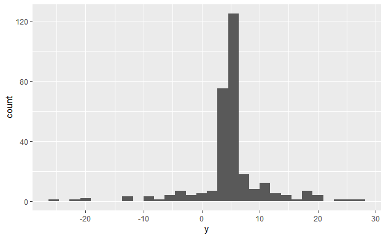

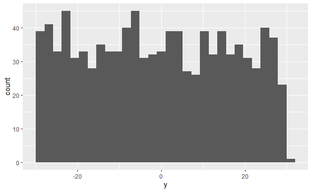

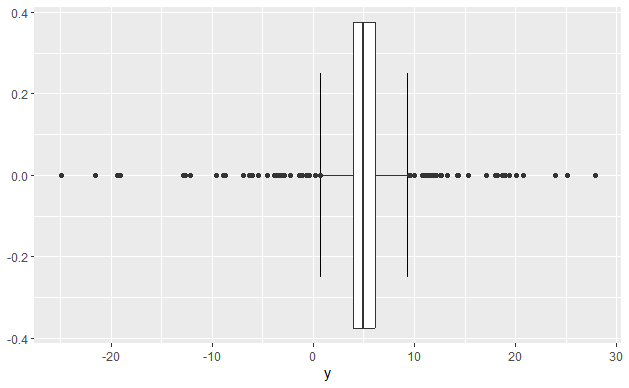

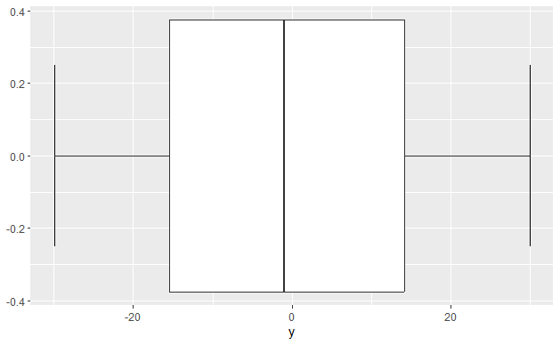

# Skewness in Box Plots

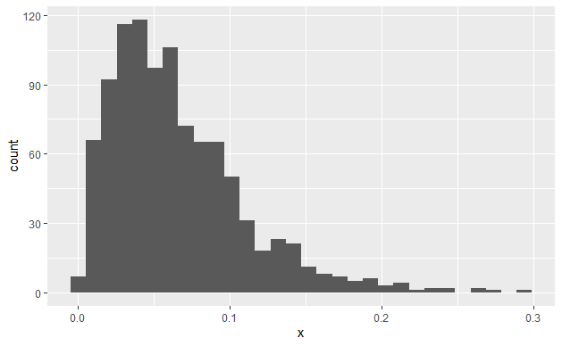

| position | var |
| --- | --- |
| Accounting | 5681909 |
| Management | 119695746 |

| position | sd |
| --- | --- |
| Accounting | 2383.676 |
| Management | 10940.555 |

# Common distributions

## Cumulative distribution functions (CDF)

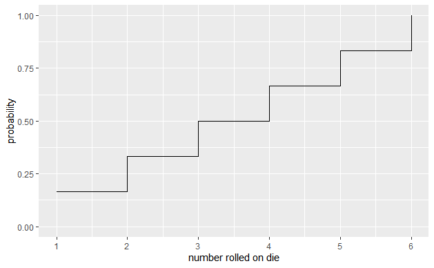

```r
dice %>%
  ggplot(aes(x = x, y = F_x)) +
  geom_step() +
  labs(x = "number rolled on die",
       y = "probability") +
  scale_x_continuous(breaks = 1:6) +
  scale_y_continuous(breaks = seq(0, 1, 0.1)) +
  ylim(0, 1)
```

## Continuous distributions

### Continuous uniform

“brain breaks” at Codeclan example - breaks were monitored for a week and found to be distributed uniformly between 5 and 22 minutes

l is our “length” variable in minutes

this is continuous.

What will the probability density function f(l) for the continuous random variable l look like?

R functions we can use: - a uniform density function `dunif(x, min, max)` - a cumulative density function `punif(q, min, max)`

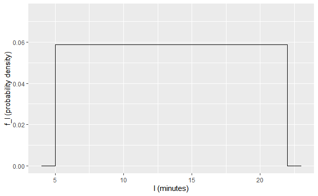

How do we use continuous CDF? Just as we did for the discrete CDF: like so -

> What is the probability of a brain break lasting between 8.4 and 10.751 mins?

```r
punif(q = 10.751, min = 5, max =22) - punif(q = 8.4, min = 5, max = 22)
```

```
[1] 0.1382941
```

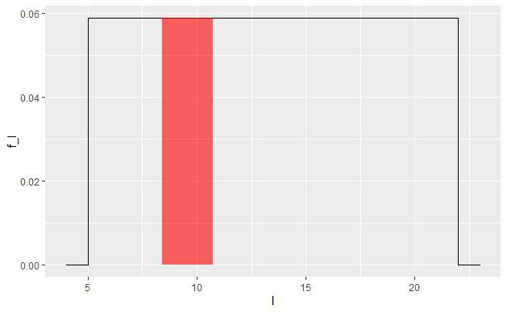

```r
brain_breaks %>%
  ggplot(aes(x = l, y = f_l)) +
  geom_line() +
  geom_ribbon(aes(ymin = 0,
                  ymax = ifelse(l >= 8.4 & l <= 10.751, f_l, 0)),
              fill = "red",
              alpha = 0.6)
```

## Normal distributions

Let’s plot the probability density for a normal distribution to get a sense of what it looks like

We’ll use `dnorm(x, mean, sd)` function - this provides the normal probability density.

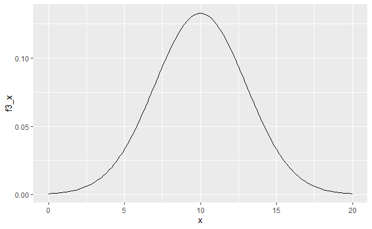

```r
three_norms <- tibble(
  x = seq(0, 20, 0.1),
  f1_x = dnorm(x = x, mean = 10, sd = 1),
  f2_x = dnorm(x = x, mean = 10, sd = 2),
  f3_x = dnorm(x = x, mean = 10, sd = 3)
)

three_norms %>%
  ggplot() +
  geom_line(aes(x = x, y = f3_x), col = "black")
```

Let’s plot all three together to compare.

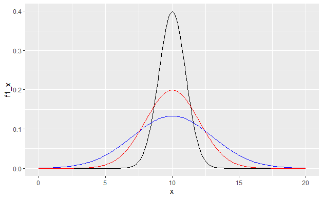

```r
three_norms %>%
  ggplot() +
    geom_line(aes(x = x, y = f1_x), col = "black") +
    geom_line(aes(x = x, y = f2_x), col = "red") +
    geom_line(aes(x = x, y = f3_x), col = "blue")
```

## fitting a normal disribution to a data set

if we have a data set that we believe is normally distributed, we can “fit” a normal distribution to the probability distribution or density by calculating the mean and sd of the data

```r
library(janitor)

accounts_salary_stats <- jobs %>%
  filter(position == "Accounting") %>%
  summarise(
    num = n(),
    mean = mean(salary),
    sd = sd(salary)
  )
```

Now let’s fit a normal distribution to our data:

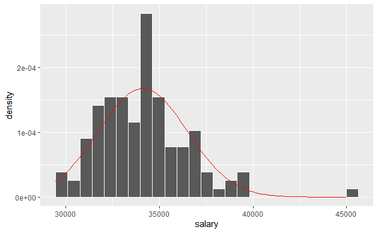

```r
jobs %>%
  filter(position == "Accounting") %>%
  ggplot(aes(x = salary)) +
  geom_histogram(aes(y = after_stat(density)),
                      col = "white",
                      bins = 25) +
  stat_function(
    fun = dnorm,
    args = list(
      mean = accounts_salary_stats$mean,
      sd = accounts_salary_stats$sd
    ),
    col = "red"
  )
```

## Standard normal

Often, we describe a normal distribution in terms of a **standardised variable**, which is called `z` by convention.

Z just tells us how far away we are from the mean (the center of the distribution), and the sign tells us the direction.

e.g. z = -1 tells us we are “one SD below the mean” z = 2.6 tells us we are “2.6 SDs above the mean”

```r
management_scaled <- jobs %>%
  filter(position == "Management") %>%
  mutate(z_salary = scale(salary))
```

Now let’s look for outliers based upon z-scores beyond z = +- 3

| x1 | position | salary | z_salary |
| --- | --- | --- | --- |
| 108 | Management | 91027 | 3.66991 |

If we use z rather than x in the normal equation, it assumed a simpler form known as the **standard normal distribution** - this would have mean = 0, SD = 1

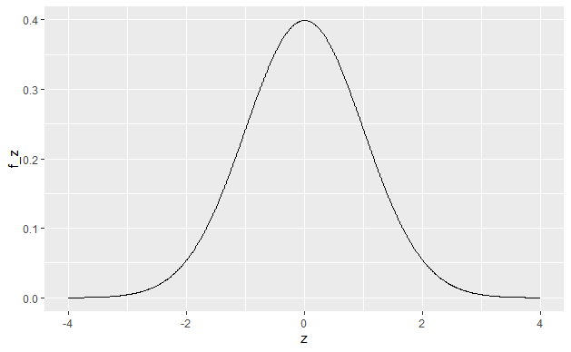

What about the standard normal CDF?

This works in exactly the same way as for the continuous uniform distribution above: we provide a z-value, and R provides the probability of the random variable taking a value less than or equal to that z-value.

e.g.

> what is the prob of the standard normally distributed random variable z, assuming a value z <= 0?

```r
# first, let's get the prob z <= 0
pnorm(q = 0)
```

```
[1] 0.5
```

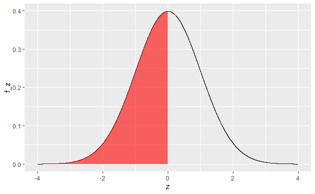

```r
shade_standard_normal <- function(shade_from, shade_to){
  standard_normal <- tibble(
    z = seq(from = -4, to = 4, by = 0.001),
    f_z = dnorm(x = z)
  )
  standard_normal %>%
    ggplot(aes(x = z, y = f_z)) +
    geom_line() +
    geom_ribbon(aes(ymin = 0, ymax = ifelse(z >= shade_from & z <= shade_to, f_z, 0)), fill = "red", alpha = 0.6)
}

shade_standard_normal(shade_from = -Inf, shade_to = 0)
```

## The empirical 3 SD rule

We’ve said that most values lie within 3 SDs of the mean - we can calculate the %s of values lying within 1, 2, and 3 SDs of the mean

## Within 1 SD

```r
100 * (pnorm(q = 1) - pnorm(q = -1))
```

```
[1] 68.26895
```

```r
shade_standard_normal(shade_from = -1, shade_to = 1)
```

[output not shown]

## Within 2 SDs

```r
100 * (pnorm(q = 2) - pnorm(q = -2))
```

```
[1] 95.44997
```

[figure not shown]

## Within 3 SDs

```r
100 * (pnorm(q = 3) - pnorm(q = -3))
```

```
[1] 99.73002
```

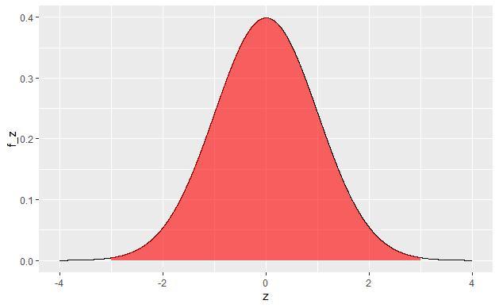

```r
shade_standard_normal(shade_from = -3, shade_to = 3)
```

We call these results the **empirical 3 SD rule**, or the **68-95-99.7 rule**